# Máster Universitario en Ciencia de Datos

# Tipología y ciclo de vida de los datos: Práctica 2

Rubén Moya Vázquez rmoyav@uoc.edu

04/01/2022

# 1 Carga de datos

Comenzaremos por cargar los datos del csv en un dataframe, para ello ejecutamos el siguiente código. Para simplificar el acceso a los datos, renombraremos las columas de la siguiente manera: * Temperature..K. -> temperature * Luminosity.L.Lo. -> luminosity * Radius.R.Ro. -> radius * Absolute.magnitude.Mv. -> magnitude * Star.type -> type * Star.color -> color * Spectral.Class -> spectral_class

```r
# Cargamos los datos en nuestro dataset.
stars <- read.csv('../data/6 _class_csv.csv', sep = ",",  stringsAsFactors = FALSE)
names(stars) <- c("temperature", "luminosity", "radius", "magnitude", "type", "color", "spectral_class")
# Mostramos los primer y últimos 6 valores para observar que la carga
# se ha realizado correctamente.
head(stars)
```

```
##   temperature luminosity radius magnitude type color spectral_class
## 1        3068   0.002400 0.1700     16.12    0   Red              M
## 2        3042   0.000500 0.1542     16.60    0   Red              M
## 3        2600   0.000300 0.1020     18.70    0   Red              M
## 4        2800   0.000200 0.1600     16.65    0   Red              M
## 5        1939   0.000138 0.1030     20.06    0   Red              M
## 6        2840   0.000650 0.1100     16.98    0   Red              M
```

```r
tail(stars)
```

```
##     temperature luminosity radius magnitude type      color spectral_class
## 235       21904     748490   1130     -7.67    5 Blue-white              B
## 236       38940     374830   1356     -9.93    5       Blue              O
## 237       30839     834042   1194    -10.63    5       Blue              O
## 238        8829     537493   1423    -10.73    5      White              A
## 239        9235     404940   1112    -11.23    5      White              A
## 240       37882     294903   1783     -7.80    5       Blue              O
```

# 2 Limpieza de datos

A continuación, veremos la estructura de los datos y si es necesario realizar una limpieza de valores nulos:

```r
str(stars)
```

```
## 'data.frame':    240 obs. of  7 variables:
##  $ temperature   : int  3068 3042 2600 2800 1939 2840 2637 2600 2650 2700 ...
##  $ luminosity    : num  0.0024 0.0005 0.0003 0.0002 0.000138 0.00065 0.00073 0.0004 0.00069 0.00018 ...
##  $ radius        : num  0.17 0.154 0.102 0.16 0.103 ...
##  $ magnitude     : num  16.1 16.6 18.7 16.6 20.1 ...
##  $ type          : int  0 0 0 0 0 0 0 0 0 0 ...
##  $ color         : chr  "Red" "Red" "Red" "Red" ...
##  $ spectral_class: chr  "M" "M" "M" "M" ...
```

Vemos que tenemos dos variables enteras (la temperatura en grados kelvin y el tipo de estrella), 3 variables de tipo numérico (radio, luminosidad y magnitud) y 2 del tipo carácter (color y clase espectral).

## 2.1 Factorización de columnas

Antes de limpiar los posibles valores nulos vamos a normalizar los valores de las variables color y spectral_class para convertirlas en factores.

```r
# Buscamos los valores diferentes que puedan ser normalizados en la columna color
unique(stars$color)
```

```
##  [1] "Red"                "Blue White"         "White"
##  [4] "Yellowish White"    "Blue white"         "Pale yellow orange"
##  [7] "Blue"               "Blue-white"         "Whitish"
## [10] "yellow-white"       "Orange"             "White-Yellow"
## [13] "white"              "Blue "              "yellowish"
## [16] "Yellowish"          "Orange-Red"         "Blue white "
## [19] "Blue-White"
```

```r
# Vemos que hay varios valores que son asimilables al mismo pero con erratas tipográficas
stars$color[stars$color == "Blue White"] <- "Blue-White"
stars$color[stars$color == "Blue white "] <- "Blue-White"
stars$color[stars$color == "Blue white"] <- "Blue-White"
stars$color[stars$color == "Blue-white"] <- "Blue-White"
stars$color[stars$color == "Blue "] <- "Blue"
stars$color[stars$color == "white"] <- "White"
stars$color[stars$color == "yellowish"] <- "Yellowish"
stars$color[stars$color == "yellow-white"] <- "White-Yellow"
stars$color[stars$color == "Yellowish White"] <- "White-Yellow"
stars$color[stars$color == "Pale yellow orange"] <- "Yellow-Orange"

# Convertimos la columna en factor
stars$color <- as.factor(stars$color)

# Convertimos la columna type en factor
stars$type <- factor(stars$type, levels = c(0, 1, 2, 3, 4, 5), labels = c("Brown Dwarf", "Red Dwarf", "White Dwarf", "Main Sequence", "Supergiant", "Hypergiant"))
```

```r
# Hacemos lo mismo con la columna spectral_class
unique(stars$spectral_class)
```

```
## [1] "M" "B" "A" "F" "O" "K" "G"
```

```r
# En este caso observamos que los valores son los correctos, asi que factorizamos
stars$spectral_class <- as.factor(stars$spectral_class)
```

## 2.2 Gestión de valores nulos

Ahora pasaremos a comprobar si hay valores nulos en alguna de las columnas de nuestro conjunto de datos. Haremos la comprobación en las columnas numéricas y en las enteras, ya que tanto en type como en las columnas factores sabemos que no hay.

```r
any(is.na(stars$temperature))
```

```
## [1] FALSE
```

```r
any(is.na(stars$luminosity))
```

```
## [1] FALSE
```

```r
any(is.na(stars$radius))
```

```
## [1] FALSE
```

```r
any(is.na(stars$magnitude))
```

```
## [1] FALSE
```

Estos cuatro valores “FALSE” nos indican que no hay ningún valor nulo en nuestro conjunto de datos. De todas formas, eso es algo que ya nos indicaban en la información del dataset de Kaggle.

## 2.3 Gestión de valores extremos.

En primer lugar, utilizaremos diagramas de cajas para buscar los posibles valores extremos en las columnas de nuestro dataset.

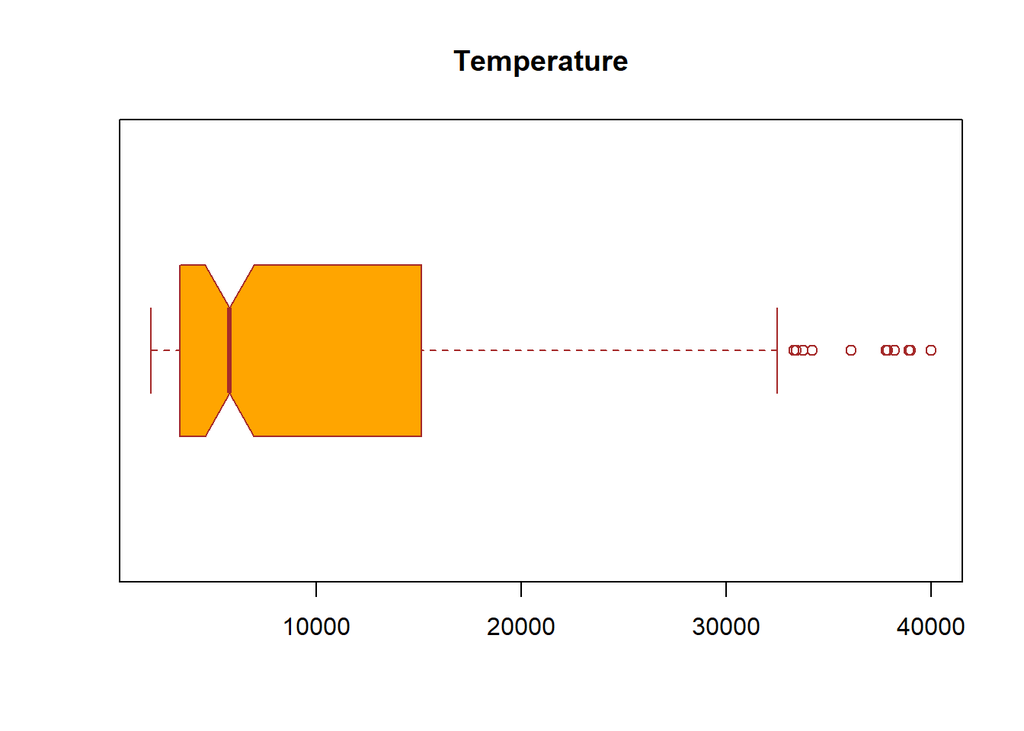

```r
boxplot(stars$temperature, main = "Temperature", col = "orange", border = "brown", horizontal = TRUE, notch = TRUE)
```

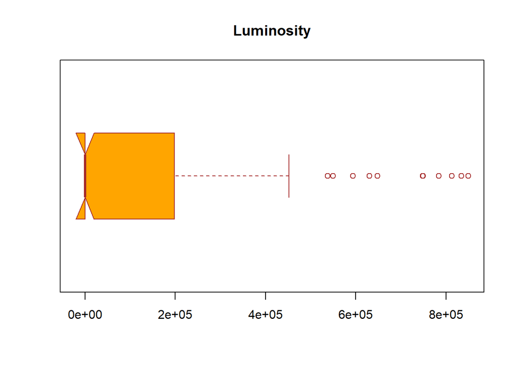

```r
boxplot(stars$luminosity,  main = "Luminosity", col = "orange", border = "brown", horizontal = TRUE, notch = TRUE)
```

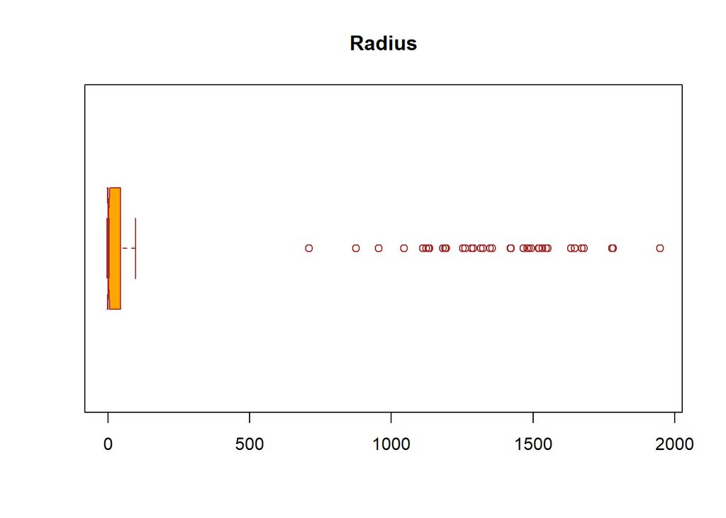

```r
boxplot(stars$radius,  main = "Radius", col = "orange", border = "brown", horizontal = TRUE, notch = TRUE)
```

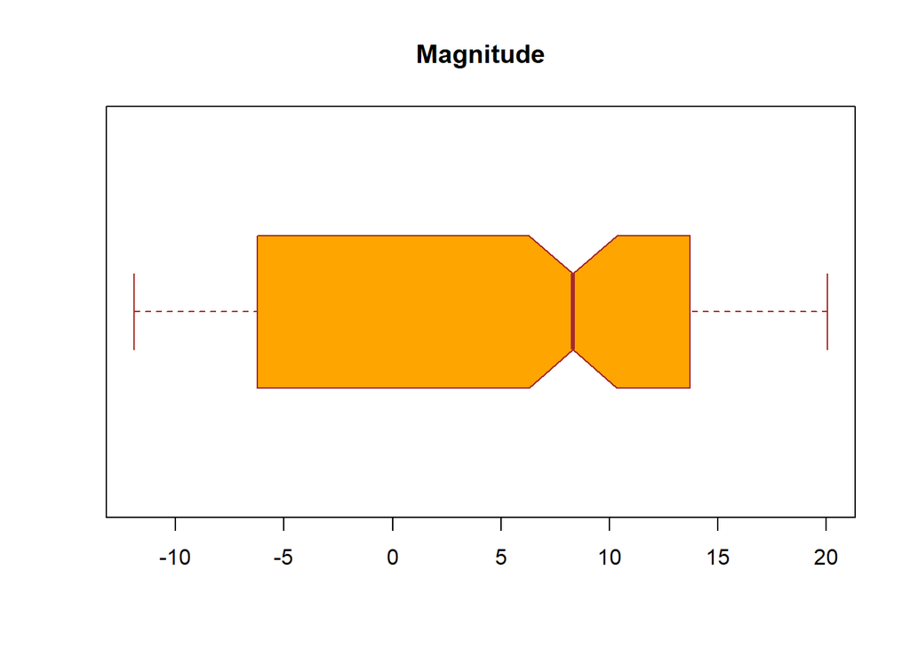

```r
boxplot(stars$magnitude,  main = "Magnitude", col = "orange", border = "brown", horizontal = TRUE, notch = TRUE)
```

Las gráficas mostradas nos hacen pensar que en los tres primeros casos podríamos encontrarnos ante distribuciones log-normales, mientras que en la ultima, no observamos ningún outlier. Para asegurarnos de que en los casos anteriores nos hayamos ante distribuciones log-normales, estudiaremos sus histogramas.

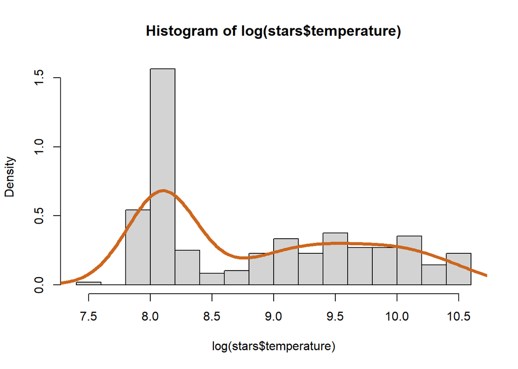

```r
hist(log(stars$temperature), breaks = 16, prob = TRUE)
lines(density(log(stars$temperature)), lwd = 4, col = "chocolate3")
```

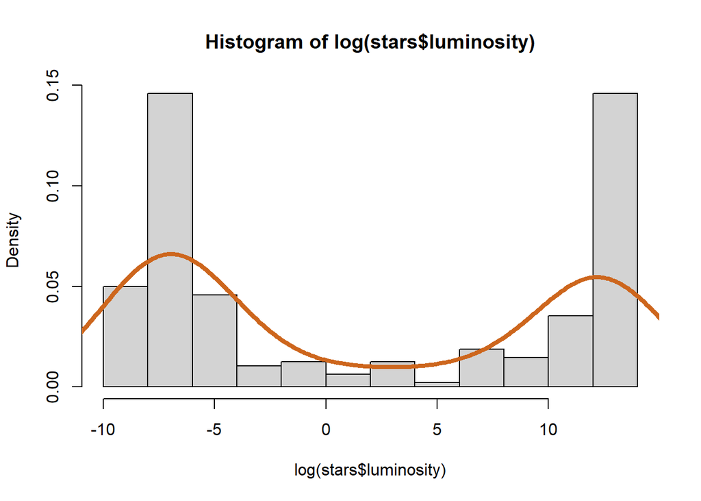

```r
hist(log(stars$luminosity), breaks = 16, prob = TRUE)
lines(density(log(stars$luminosity)), lwd = 4, col = "chocolate3")
```

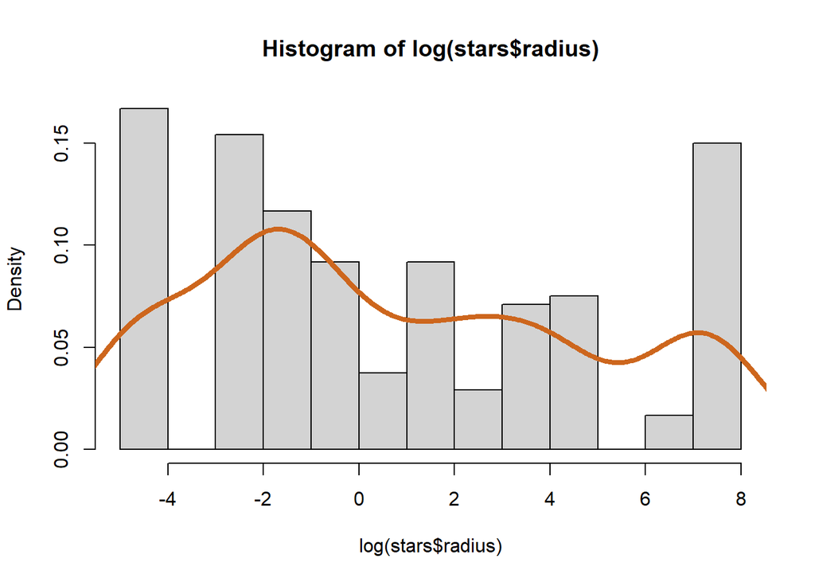

```r
hist(log(stars$radius), breaks = 16, prob = TRUE)
lines(density(log(stars$radius)), lwd = 4, col = "chocolate3")
```

Como podemos ver, ninguna de las distribuciones sigue la estructura de campana de Gauss presente en una distribución normal, así que podemos descartar que sean distribuciones log-normales sin necesidad de realizar más pruebas.

Finalmente, en cuanto a los valores extremos, hemos decidido contemplarlos en nuestro análisis sin modificarlos. Esta decisión se ha tomado teniendo en cuenta que dichos valores responden a mediciones reales que, dado el pequeño tamaño de la muestra, pueden ser demasiado variadas como para mostrar una distribución normal. Además, consideramos que, en este punto, desconocemos la relevancia de dichos valores extremos como para descartarlos o modificarlos de antemano.

# 3 Análisis de los Datos

## 3.1 Selección de los grupos de datos que se quieren analizar

A continuación agruparemos los datos en función de diversos criterios para formar subconjuntos que puedan resultar interesantes para su análisis. Realizaremos varios conjuntos y no necesariamente todos ellos serán utilizados durante el análisis final.

```r
# Por tipo de estrella
stars.brown_dwarfs <- stars[stars$type == 0, ]
stars.red_dwarfs <- stars[stars$type == 1, ]
stars.white_dwarfs <- stars[stars$type == 2, ]
stars.main_sequence <- stars[stars$type == 3, ]
stars.supergiant <- stars[stars$type == 4, ]
stars.hypergiant <- stars[stars$type == 5, ]

# Por clase espectral
stars.O <- stars[stars$spectral_class == "O", ]
stars.B <- stars[stars$spectral_class == "B", ]
stars.A <- stars[stars$spectral_class == "A", ]
stars.F <- stars[stars$spectral_class == "F", ]
stars.G <- stars[stars$spectral_class == "G", ]
stars.K <- stars[stars$spectral_class == "K", ]
stars.M <- stars[stars$spectral_class == "M", ]

# Por color
stars.red <- stars[stars$color == "Red", ]
stars.blue <- stars[stars$color == "Blue", ]
stars.white <- stars[stars$color == "White", ]
```

## 3.2 Comprobación de la normalidad y homogeneidad de la varianza

### 3.2.1 Estudio de la normalidad

Vamos a estudiar brevemente si alguna de nuestras variables numéricas sigue una distribución normal. Para ello, nos serviremos de la prueba de normalidad de Anderson-Darling.

```r
library(nortest)

alpha = 0.05
col.names = colnames(stars)
print("Las variables numéricas que no siguen una distribución normal son:")
```

```
## [1] "Las variables numéricas que no siguen una distribución normal son:"
```

```r
for (i in 1:ncol(stars)) {
  if (is.numeric(stars[,i])) {
    p_val = ad.test(stars[,i])$p.value
    if (p_val < alpha) {
      print(col.names[i])
    }
  }
}
```

```
## [1] "temperature"
## [1] "luminosity"
## [1] "radius"
## [1] "magnitude"
```

Es decir, ninguna de nuestras variables numéricas sigue una distribución normal, pero… ¿Podrían seguirla?

Vamos a analizar si alguna de nuestras variables podría ser candidata a la normalización mediante el estudio de las gráficas quantile-quantile y su histograma.

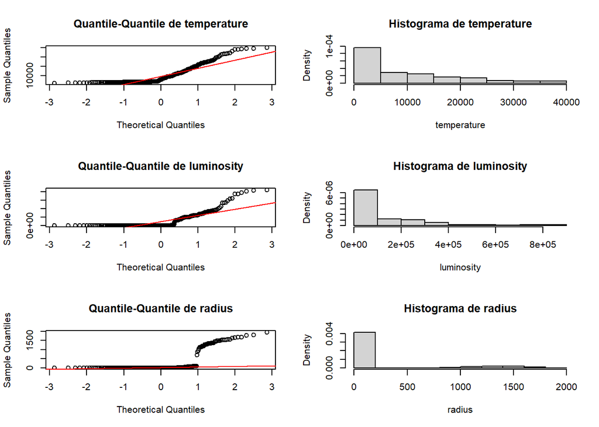

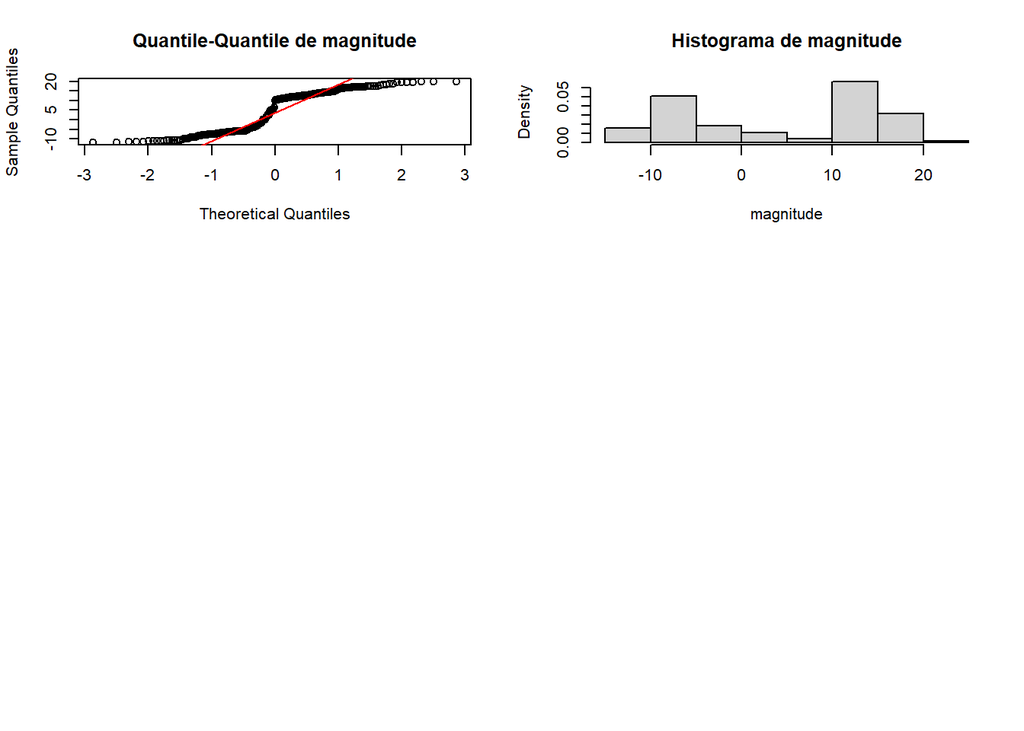

```r
par(mfrow=c(3,2))
for(i in 1:ncol(stars)) {
  if (is.numeric(stars[,i])){
    qqnorm(stars[,i],main = paste("Quantile-Quantile de",colnames(stars)[i]))
    qqline(stars[,i],col="red")
    hist(stars[,i],
      main=paste("Histograma de", colnames(stars)[i]),
      xlab=colnames(stars)[i], freq = FALSE)
  }
}
```

Estos resultados nos muestran que varias de nuestras variables numéricas pueden ser candidatas a la normalización. De todas formas, descartaremos este proceso debido a que queremos que se estudien los datos reales de las mediciones de nuestro conjunto de estrellas.

### 3.2.2 Estudio de la homogeneidad de la varianza

Para estudiar la homogeneidad de la varianza utilizaremos el test de Levene que nos permite realizar comparaciones de varianzas con 2 o más conjuntos de elementos.

```r
library(car)
leveneTest(y = stars$temperature, group = stars$type, center = "median")
```

```
## Levene's Test for Homogeneity of Variance (center = "median")
##        Df F value    Pr(>F)
## group   5  16.063 1.316e-13 ***
##       234
## ---
## Signif. codes:  0 '***' 0.001 '**' 0.01 '*' 0.05 '.' 0.1 ' ' 1
```

```r
leveneTest(y = stars$luminosity, group = stars$type, center = "median")
```

```
## Levene's Test for Homogeneity of Variance (center = "median")
##        Df F value    Pr(>F)
## group   5  20.122 < 2.2e-16 ***
##       234
## ---
## Signif. codes:  0 '***' 0.001 '**' 0.01 '*' 0.05 '.' 0.1 ' ' 1
```

```r
leveneTest(y = stars$radius, group = stars$type, center = "median")
```

```
## Levene's Test for Homogeneity of Variance (center = "median")
##        Df F value    Pr(>F)
## group   5  59.322 < 2.2e-16 ***
##       234
## ---
## Signif. codes:  0 '***' 0.001 '**' 0.01 '*' 0.05 '.' 0.1 ' ' 1
```

```r
leveneTest(y = stars$magnitude, group = stars$type, center = "median")
```

```
## Levene's Test for Homogeneity of Variance (center = "median")
##        Df F value    Pr(>F)
## group   5  30.877 < 2.2e-16 ***
##       234
## ---
## Signif. codes:  0 '***' 0.001 '**' 0.01 '*' 0.05 '.' 0.1 ' ' 1
```

Vemos que los resultados de estos test nos hacen percatarnos de que las varianzas de nuestros grupos de datos no son homogeneas en todos los casos.

# 4 Pruebas estadísticas

## 4.1 ¿Las estrellas de la secuencia principal son más luminosas que las enanas blancas?

En nuestro caso, planteamos el contraste de hipótesis de dos muestras sobre la diferencia de medias, unilatera, con un nivel de confianza del 95%

**H0: μ1 − μ2 = 0**

**H1: μ1 − μ2 < 0**

```r
# Comentado para poder hacer el knit
#t.test(stars.main_sequence$luminosity, stars.white_dwarfs$luminosity, alternative = "less")
```

## 4.2 Random forest con k-fold cross validation

A continuación vamos a aplicar un modelo de predicción conocido por su efectividad como es el Random forest con la metodología k-fold de validación cruzada, de manera que nos permita elaborar un modelo de predicción eficaz para la clasificación de estrellas en base a nuestro conjunto de datos. Gracias al uso de la validación cruzada nos evitaremos el problema de tener un algoritmo sobreentrenado, lo cual es un problema comun en este tipo de modelos.

```r
library(randomForest)
library(caTools)
library(caret)

set.seed(12)

# Creamos los grupos de entrenamiento y test
split <- sample.split(stars$type, SplitRatio = 0.80)
training_set <- subset(stars, split == TRUE)
test_set <- subset(stars, split == FALSE)
folds <- createFolds(training_set$type, k = 10)

# Creamos nuestro random forest con cross validation
cvRandomForest <- lapply(folds, function(x){
  training_fold <- training_set[-x, ]
  test_fold <- training_set[x, ]
  clasifier <- randomForest(type ~ ., data = training_fold, ntree = 25)
  y_pred <- predict(clasifier, newdata = test_fold)
  cm <- table(test_fold$type, y_pred)
  precision <- (cm[1,1] + cm[2,2]) / (cm[1,1] + cm[2,2] +cm[1,2] + cm[2,1])
  return(precision)
})

# Precisión obtenida
precisionRandomForest <- mean(as.numeric(cvRandomForest))
print("Precisión de nuestro modelo:")
```

```
## [1] "Precisión de nuestro modelo:"
```

```r
precisionRandomForest
```

```
## [1] 0.9857143
```

Como podemos ver, el modelo final tiene una precisión muy alta: 98.57%.

Ahora visualizaremos de manera un poco más grafica los resultados de predecir clasificaciones con nuestro modelo gracias a su matriz de confusión:

```r
clasificadorRF <- randomForest(type ~ ., data = training_set, ntree = 25)
y_pred <- predict(clasificadorRF, newdata = test_set)
cm <- table(test_set$type, y_pred)
cm
```

```
##                y_pred
##                 Brown Dwarf Red Dwarf White Dwarf Main Sequence Supergiant
##   Brown Dwarf             8         0           0             0          0
##   Red Dwarf               0         8           0             0          0
##   White Dwarf             0         0           8             0          0
##   Main Sequence           0         0           0             8          0
##   Supergiant              0         0           0             0          8
##   Hypergiant              0         0           0             0          0
##                y_pred
##                 Hypergiant
##   Brown Dwarf            0
##   Red Dwarf              0
##   White Dwarf            0
##   Main Sequence          0
##   Supergiant             0
##   Hypergiant             8
```